# How to analyze irradiance data

Maxime Durand

14/02/2020

```r
knitr::opts_knit$set(root.dir = "C:/Users/Localadmin_durandma/Dropbox/SpecS/RcodeNewExample/")
```

# How to analyze irradiance data

First of all, here is all the packages needed:

```r
# First install a version of Java if not already done (otherwise cant load rJava package)
# You might need both 32 and 64 bits versions (https://www.java.com/en/download/manual.jsp)
if(!("rJava" %in% installed.packages()[,"Package"])){
  cat("Installing the package 'rJava'", "\n")
  install.packages("rJava")
}
library(rJava)

# You will need Rtools: https://cran.r-project.org/bin/windows/Rtools/
# Once it is done, for R version 4.0, run this line and restart R
# writeLines('PATH="${RTOOLS40_HOME}\\usr\\bin;${PATH}"', con = "~/.Renviron")
# Sys.which("make") # Should show : ## "C:\\rtools40\\usr\\bin\\make.exe"


# Then install Omnidriver using Rtools
if(!("devtools" %in% installed.packages()[,"Package"])){
  cat("Installing the package 'devtools'", "\n")
  install.packages("devtools")
}
if(!("rOmniDriver" %in% installed.packages()[,"Package"])){
  cat("Installing the package 'rOmniDriver'", "\n")
  devtools::install_bitbucket("aphalo/romnidriver")
}

# Finally get the ooacquire package
if(!("ooacquire" %in% installed.packages()[,"Package"])){
  cat("Installing the package 'ooacquire'", "\n")
  devtools::install_bitbucket("aphalo/ooacquire")
}

source("C:/Users/Localadmin_durandma/Dropbox/Work/R/Misc/Rutils.R")
source("C:/Users/Localadmin_durandma/Dropbox/Work/R/Spectral_Irr/SpecUtils.R")

# Then load rest of the packages downloadable from CRAN
#library(readxl)
library(xlsx)
library(photobiology)
library(photobiologyWavebands)
library(photobiologyPlants)
library(ooacquire)##http://docs.r4photobiology.info/oocquire/vignettes/user-guide.html
###take function s_irrad_corrected and the calibration files from the package
library(ggplot2)
library(ggspectra)
library(ggrepel)
library(ggpmisc)
library(signal)
library(RColorBrewer)
library(fda.usc)
```

With every measurments (100 scans), 2 more spectra are taken. The first one, the **dark scan**, to correct for dark noise taken using a dark cap over the diffuser blocking UV and visible solar radiation. The second one, the **stray-light correction for the UV**, is taken using a polycarbonate cap over the diffuser blocking solar UV radiation (UV-B 280–315 nm plus UV-A 315–400 nm).

All three scans are imported in R:

```r
# Define the name of the files tobe imported, and their identity (dark is dark scan, FC is UV correction)
irrad <- list(light = "12asnow.txt", filter = "12asnowPC.txt", dark = "12asnowdark.txt")
```

Here is what they look like:

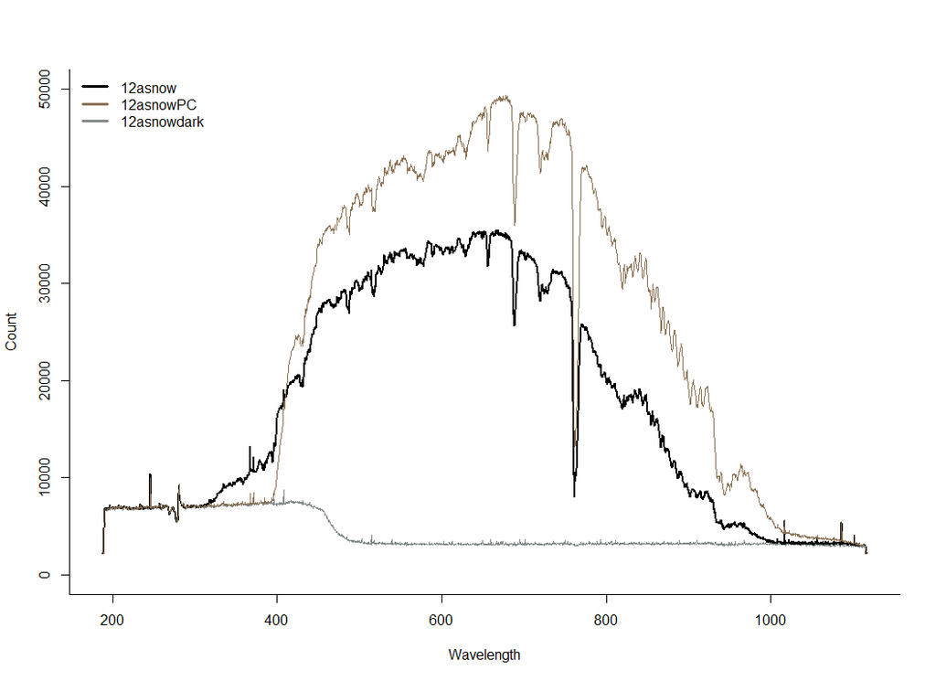

The specta are then imported in a special class. A correction method and a descriptor are chosen based on the measuring device and the date, respectively.

```r
raw.mspct <- ooacquire::read_files2mspct(files = irrad, descriptor = which_descriptor("2017-10-06"))
raw.mspct
```

```
## Object: raw_mspct [3 x 1]
## --- Member: light ---
## Object: raw_spct [2,068 x 2]
## Wavelength range 187.82 to 1117.14 nm, step 0.41 to 0.48 nm
## Label: File: 12asnow.txt
## Measured on 2017-02-28 12:07:51 UTC
## Data acquired with 'MayaPro2000' s.n. MAYP11278
## grating 'HC1', slit '010s'
## integ. time (s): 3.5
## total time (s): 3.5
## counts @ peak (% of max): NA
##
## # A tibble: 2,068 x 2
##    w.length counts
##       <dbl>  <dbl>
##  1     188.   2243
##  2     188.   2187
##  3     189.   2147
##  4     189.   2153
##  5     190.   4826
##  6     190.   5883
##  7     191.   6826
##  8     191.   6815
##  9     192.   6931
## 10     192.   6786
## # ... with 2,058 more rows
## --- Member: filter ---
## Object: raw_spct [2,068 x 2]
## Wavelength range 187.82 to 1117.14 nm, step 0.41 to 0.48 nm
## Label: File: 12asnowPC.txt
## Measured on 2017-02-28 12:13:03 UTC
## Data acquired with 'MayaPro2000' s.n. MAYP11278
## grating 'HC1', slit '010s'
## integ. time (s): 3.5
## total time (s): 3.5
## counts @ peak (% of max): NA
##
## # A tibble: 2,068 x 2
##    w.length counts
##       <dbl>  <dbl>
```

[output cut: 23 more lines]

```
##    w.length counts
##       <dbl>  <dbl>
##  1     188.   2240
##  2     188.   2184
##  3     189.   2148
##  4     189.   2149
##  5     190.   4812
##  6     190.   5764
##  7     191.   6648
##  8     191.   6724
##  9     192.   6711
## 10     192.   6694
## # ... with 2,058 more rows
##
## --- END ---
```

```r
correction.method = MAYP11278_sun.mthd
```

After that, a number of corrections are done on each spectra:

## 1. Removing bad pixels

Bad pixels are stored in the decriptor object (“bad.pixs”). The function works for multiple columns with the name "*counts". The bad pixels are replaced by the average of the pixel before and after.

```r
temp.spct <- raw.mspct[["light"]] #Select one spectrum

skip_bad_pixs <- function(x) {
  stopifnot(is.raw_spct(x))
  bad.pixs <- getInstrDesc(x)[["bad.pixs"]]
  if (length(bad.pixs) == 0) {
    # nothing to do
    return(x)
  }
  counts.cols <- grep("^counts", names(x), value = TRUE)
  for (col in counts.cols) {
    x[bad.pixs, col] <-
      (x[bad.pixs - 1, col] + x[bad.pixs + 1, col]) / 2
  }
  x
}

temp.spct <- skip_bad_pixs(temp.spct)
```

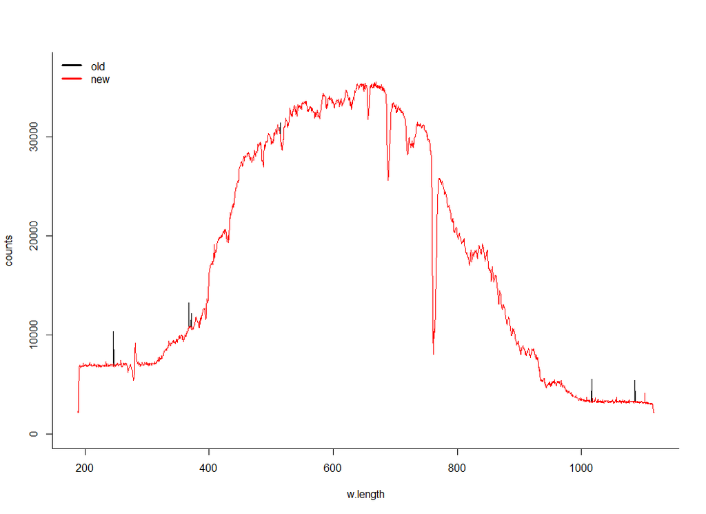

## 2. Replace out-of-range instrument counts

This function will replave by NA “out-of-range” counts values. The maximum number of counts is found in the descriptor object (“max.counts”). You can specify the range (by default -Inf to max.counts) and what fill in (by default NA). Also works for multiple counts columns.

```r
trim_counts <- function(x,
                        range = c(NA, getInstrDesc(x)[["max.counts"]] - 1),
                        fill = NA) {
  stopifnot(is.raw_spct(x))
  if (is.na(range[1])) {
    range[1] <- -Inf
  }
  if (is.na(range[2])) {
    range[2] <- Inf
  }
  counts.cols <- grep("^counts", names(x), value = TRUE)
  for (col in counts.cols) {
    if (min(x[[col]]) < 0) {
      warning("Negative raw counts in data!\n",
              "These are not raw detector counts.")
    }
    x[[col]] <- ifelse(x[[col]] < range[1] | x[[col]] > range[2],
                       fill,
                       x[[col]])
  }
  x
}

temp.spct <- trim_counts(temp.spct)
```

## 3. Expand NA’s to neighbouring pixels

Replace neighbouring pixels of NA’s with NA. This is because of a phenomenon similar to “blooming” in camera sensors whereby when a sensor well gets saturated some of the charge migrates to adjacent wells in the detector increasing their readings.

```r
bleed_nas <- function(x, n = 10) {
  stopifnot(is.raw_spct(x))
  counts.cols <- grep("^counts", names(x), value = TRUE)
  # this is a "quick and dirty" algorithm that assumes that we do not need to
  # check for NAs the first n and last n pixels of the detector array, which in
  # practice are almost never used for anything but dark reference and so very
  # unlikely to be exposed to an irradiance saturating their response.
  z <- x
  for (i in counts.cols) {
    for (j in n:(nrow(x) - n)) {
      if (anyNA(x[(j-n):(j+n), i])) {
        z[j, i] <- NA
      }
    }
  }
  z
}

temp.spct <- bleed_nas(temp.spct)
```

## 4. Apply linearization correction to raw counts data

Linearization correction is in “inst.calib$nl.fun” of the descriptor object. A number of checks are done to see whether linearization is already done and if the linearization function in found.

The calibration look like this

```
## Descriptor cal_2016a selected for 2017-10-06
```

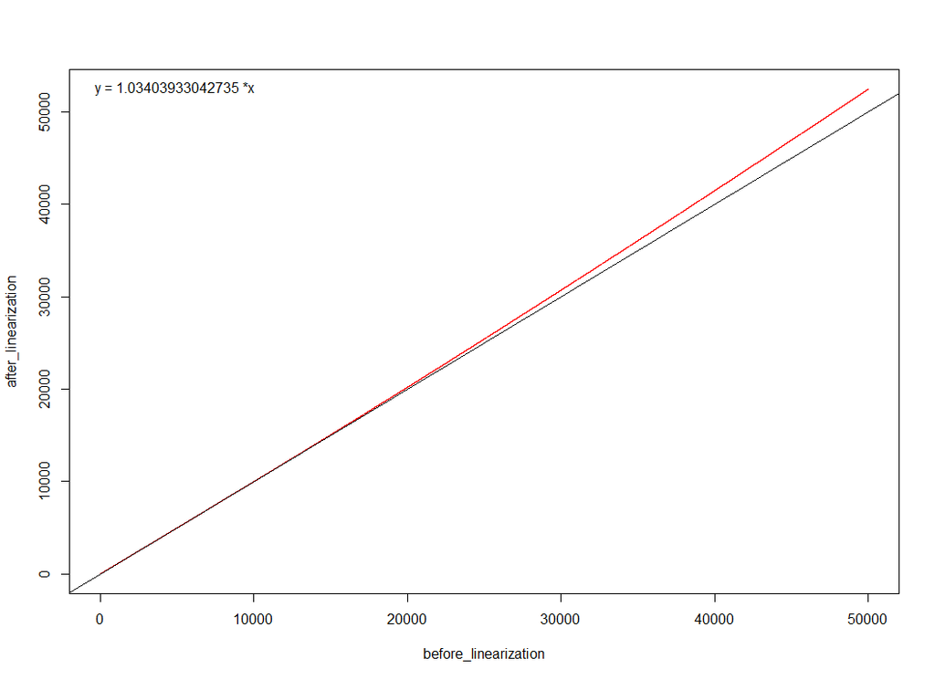

```r
linearize_counts <- function(x,
                             force.zero = TRUE,
                             verbose = getOption("photobiology.verbose", default = FALSE)) {
  # guard against attempts to reapply linearization
  settings <- getInstrSettings(x)
  if (length(settings[["linearized"]]) == 0L) {
    warning("Linearized attr is NULL, assuming FALSE")
  } else if (is.na(settings[["linearized"]])) {
    stop("Linearization status unknown")
  } else if (settings[["linearized"]]) {
    if (verbose) {
          message("Spectrum already linearized, returning as is.")
    }
    return(x)
  }
  descriptor <- getInstrDesc(x)
  if (length(descriptor$inst.calib) == 0L ||
      !is.list(descriptor$inst.calib) ||
#      is.na(descriptor$inst.calib[[1L]]) ||
      !is.function(descriptor$inst.calib$nl.fun)) {
    stop("Non-linearity correction function is not available")
  }
  nl.fun <- descriptor$inst.calib$nl.fun
  counts.cols <- names(x)[grep("^counts", names(x))]
  for (col in counts.cols) {
    if (force.zero) {
      x[[col]] <- ifelse(x[[col]] >= 0.0, x[[col]], 0.0)
      x[[col]] <- nl.fun(x[[col]])
    }
  }
  settings[["linearized"]] <- TRUE
  setInstrSettings(x, settings)
  x
}

temp.spct <- linearize_counts(temp.spct)
```

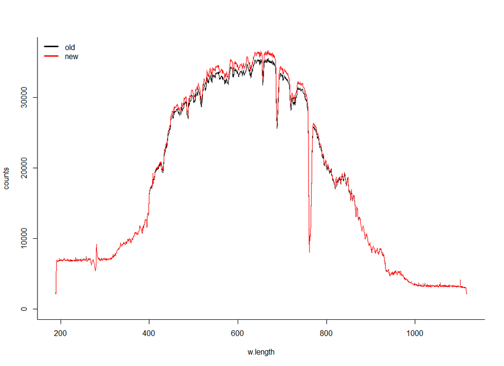

## 5. Shift data to center it to zero based on a set of values

Here the set of values is the first 4, there aretaken in the correction.method object (inst.dark.pixs). The average count of these 4 wavelength is taken as the zero (*i.e.* this average is substracted to every wavelength of the spectrum).

```r
inst.dark.pixs = 1:4
inst.dark.wl <- range(temp.spct[["w.length"]][inst.dark.pixs])
temp.spct_new <- fshift(temp.spct_old, range = inst.dark.wl)
```

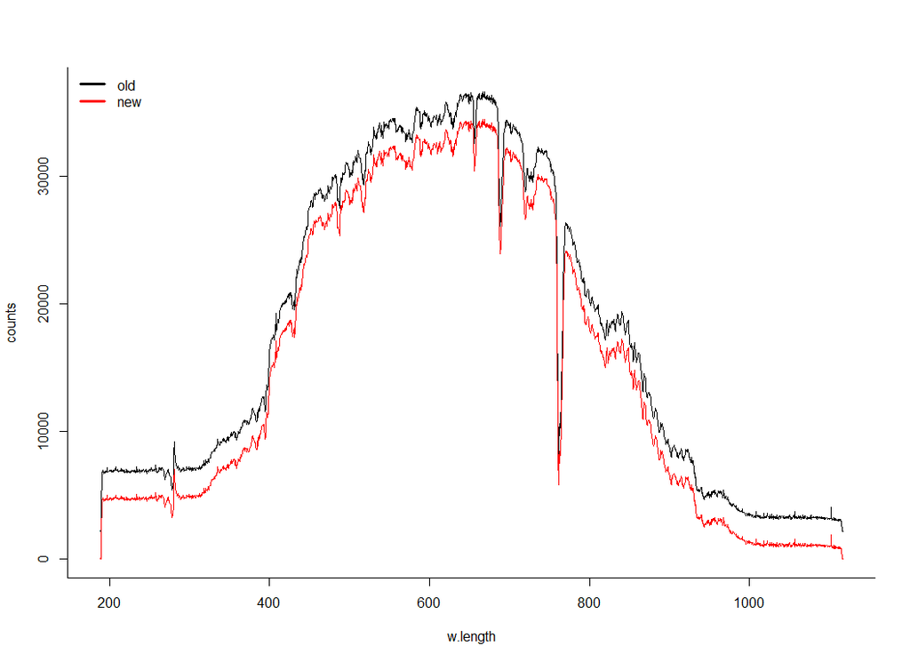

## 6. Calculate counts per seconds (cps) based on raw number of counts and integration times

Apart from bunch of other safeguard and possibilities it basically a division of CPS = Counts / intergration time. No real need to show function here.

```r
temp.spct <- raw2cps(temp.spct)
```

## 7. Merge spectra to remove NA’s

If multiple spectra are available, replace NA’s with longer integration time with cps values from shorter integration times.

```r
merge_cps <- function(x) {
  stopifnot(is.cps_spct(x))
  counts.cols <- grep("^cps", names(x), value = TRUE)
  if (length(counts.cols) == 1) {
    return(x)
  }
  instr.desc <- getInstrDesc(x)
  instr.settings <- getInstrSettings(x)
  integ.times <- instr.settings[["integ.time"]]
  num.exposures <- instr.settings[["num.exposures"]]
  if (all(num.exposures < 0L)) {
    cols <- counts.cols[order(integ.times, decreasing = TRUE)]
  } else {
    cols <- counts.cols[order(num.exposures, decreasing = TRUE)]
  }
  x[["cps"]] <- x[[cols[1]]]
  for (i in 2:length(cols)) {
    x[["cps"]] <- ifelse(is.na(x[["cps"]]),
                          x[[cols[i]]],
                          x[["cps"]] )
  }
  z <- x[ , c("w.length", "cps")]
  z <- photobiology::copy_attributes(x, z)
  z
}

temp.spct <- merge_cps(temp.spct)
```

Actually, since every spectra is subjected to these seven steps, everything can be done at once using a loop:

```r
raw2merged_cps <- function(xx, spct.names, inst.dark.pixs = NA_real_)
{
  spct.names <- intersect(spct.names, names(xx))
  zz <- cps_mspct()
  for (n in spct.names)
    {
    temp.spct <- xx[[n]]
    inst.dark.wl <-
      range(temp.spct[["w.length"]][inst.dark.pixs])
    temp.spct <- skip_bad_pixs(temp.spct)
    temp.spct <- trim_counts(temp.spct)
    temp.spct <- bleed_nas(temp.spct)
    temp.spct <- linearize_counts(temp.spct)
    if (all(!is.na(inst.dark.wl))) {
      temp.spct <- fshift(temp.spct, range = inst.dark.wl)
    }
    temp.spct <- raw2cps(temp.spct)
    zz[[n]] <- merge_cps(temp.spct)
  }
  zz
}

spct.names = c(light = "light", filter = "filter", dark = "dark")
y <- raw2merged_cps(xx = raw.mspct, spct.names = spct.names, inst.dark.pixs = correction.method$inst.dark.pixs)
```

## 8. Dark spectrum normalization

From this, the dark spectrum can be substracted to both the *actual* data, and the other spectra for *stray-light correction for the UV*. The dark specrtum is deleted after that.

```r
y <- ref_correction(y, ref_name = spct.names["dark"])
```

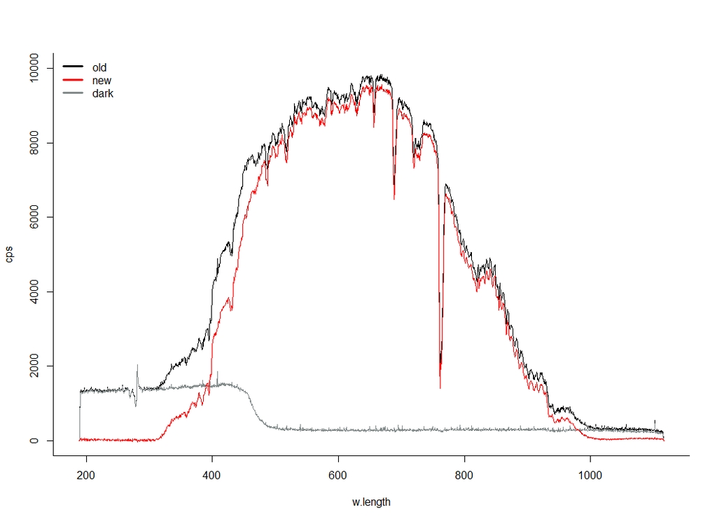

## 9. Stray light correction

Then can come the stray light correction, using the method specified in the correction.method object. You can also do the correction even if the filter spectrum was not taken (using the function no_filter_correction). The function uses waveband filtered by the filter (the range is in correction.method$flt.dark.wl), the function then compute a ratio of **filter/light** as some average over those wavebands. and use that ratio to correct the light spectum as: **corrected_light = light - filter / ratio**

```r
filter_correction <- function(x, flt, stray.light.method = "original", stray.light.wl = c(218.5, 228.5),
                              flt.dark.wl = c(193, 209.5), flt.ref.wl = c(360, 379.5), flt.Tfr = 1, trim = 0.05,
                              verbose = getOption("photobiology.verbose", default = FALSE)) {

  stopifnot(is.cps_spct(x) && is.cps_spct(flt))
  stopifnot(all(wl_range(x) == wl_range(flt)) && nrow(x) == nrow(flt))

  straylight.corrected <- attr(x, "straylight.corrected", exact = TRUE)
  if (!is.null(straylight.corrected) && !is.na(straylight.corrected) && straylight.corrected) {
    if (verbose) {
      warning("Skipping straylight correction: already corrected.")
    }
    return(x)
  }

  # check number of cps columns and merge if needed
  x   <- merge_cps(x)
  flt <- merge_cps(flt)

  # Find maximum cps
  max_x_cps <- max(x[["cps"]], na.rm = TRUE)

  # compute filter short wl "dark" cps
  if (anyNA(flt.dark.wl)) {
    mean_flt_cps_short <- 0
    mean_x_cps_short <- 0
  } else {
    flt_clip_dark <- clip_wl(flt, range = flt.dark.wl)
    x_clip_dark <- clip_wl(x, range = flt.dark.wl)

    mean_flt_cps_short <- mean(flt_clip_dark[["cps"]],
                               trim = trim, na.rm = TRUE)
    mean_x_cps_short <- mean(x_clip_dark[["cps"]],
                             trim = trim, na.rm = TRUE)
  }

  # compute filter "reference" wl cps
  flt_clip_ref <- clip_wl(flt, range = flt.ref.wl)
  x_clip_ref <- clip_wl(x, range = flt.ref.wl)

  mean_flt_cps_ref <- mean(flt_clip_ref[["cps"]],
                            trim = trim, na.rm = TRUE)
  mean_x_cps_ref <- mean(x_clip_ref[["cps"]],
                          trim = trim, na.rm = TRUE)

  # We try to avoid spureous warnings by using the mean
  if (verbose && mean_flt_cps_short < -1e4 * max_x_cps) {
    warning("Negative mean cps in \"filter\" spectrum's internal dark reference: ",
            mean_flt_cps_short)
  }

  if (verbose && mean_x_cps_short < -1e4 * max_x_cps) {
    warning("Negative mean cps in \"measured\" spectrum's internal dark reference: ",
            mean_x_cps_short)
  }

  # Lasse's first correction
  if (stray.light.method == "original") {
    if (verbose && anyNA(flt_clip_dark[["filter_ratio"]])) {
      warning(paste(sum(is.na(flt_clip_dark[["filter_ratio"]])),
                    " NAs in filter_ratio"))
    }
    flt_clip_dark[["filter_ratio"]] <-
      flt_clip_dark[["cps"]] / x_clip_dark[["cps"]]
    mean_flt_ratio_short <- mean(flt_clip_dark[["filter_ratio"]],
                                 trim = trim, na.rm = TRUE)
  } else if (stray.light.method == "full" ||
             stray.light.method == "sun" ||
             stray.light.method == "raw") {
    # attempt to avoid overcorrection
    if ((mean_x_cps_short - mean_flt_cps_short) < 0.0) {
      mean_flt_ratio_short <- 1.0
    } else {
      mean_flt_ratio_short <- mean_flt_cps_short / mean_x_cps_short
    }
  } else if (stray.light.method == "simple") {
    # trust filter spectral transmitatnce
    mean_flt_ratio_short <- flt.Tfr
  }else {
    stop(paste("stray.light.method '", stray.light.method, "' not supported"))
  }

  # diagnosis and correction of bad estimates
  if (is.na(mean_flt_ratio_short)) {
    warning("NA in mean_flt_ratio_short, skipping correction")
  } else {
    if (mean_flt_ratio_short < 0.75) {
      # This is a guess based on PC filter transmittance of 90% or more in IR.
      if (verbose || abs(mean_x_cps_short / max_x_cps) > 1e-2) {
        warning("mean_flt_ratio_short < 0.75, was ",
                signif(mean_flt_ratio_short, 4),
                "; light source emits in UVC",
                "; or instrument dark reading unstable",
                ", using 0.85")
      }
      mean_flt_ratio_short <- 0.85 # we use the actual filter transmittance
    } else if (mean_flt_ratio_short > 1.5) {
      # This is set to 1.5 as it makes no sense to have a lot more noise with the filter than without it!
      if (verbose || abs(mean_x_cps_short / max_x_cps) > 1e-2)
        warning("mean_flt_ratio_short > 1.5, was ",
                signif(mean_flt_ratio_short, 4),
                ", set to 1.5; possible stray light unstable")
      mean_flt_ratio_short <- 1.5
    } else {
      if (verbose) message("mean_flt_ratio_short is ", signif(mean_flt_ratio_short, 4))
    }
    selector <- x[["w.length"]] > flt.dark.wl[2] & x[["w.length"]] < flt.ref.wl[2]
    # Apply correction
    x[selector, "cps"] <-
      x[selector, "cps"] - flt[selector, "cps"] / mean_flt_ratio_short
  }

  # correct "long" side of spectrum for stray light
  flt_clip_ref <- clip_wl(flt, range = flt.ref.wl)
  x_clip_ref <- clip_wl(x, range = flt.ref.wl)

  mean_flt_cps_medium <- mean(flt_clip_ref[["cps"]],
                            trim = trim, na.rm = TRUE)
  mean_x_cps_medium <- mean(x_clip_ref[["cps"]],
                          trim = trim, na.rm = TRUE)

  # Because of pixel to pixel random noise this could easily be true per pixel
  if (verbose && mean_flt_cps_medium < 0.0) {
    warning("Mean cps of ", mean_flt_cps_medium,
            " in reference region of \"filter\" scan!")
  }

  if (verbose && mean_x_cps_medium < 0.0) {
    warning("Mean cps of ", mean_x_cps_medium,
            " in reference region of \"measurement\" scan!")
  }

  if (verbose && ((mean_flt_cps_medium / mean_flt_cps_short) > 1.0)) {
    message("There is more noise at ", flt.ref.wl[1], " to ", flt.ref.wl[2],
            " nm than at ", flt.dark.wl[1],
            " to ", flt.dark.wl[2], " nm, ratio: ",
            signif(mean_flt_cps_medium / mean_flt_cps_short, 4))
  }

  selector <- x[["w.length"]] >= flt.ref.wl[2]
  stray_light_correction <- mean_flt_cps_medium / mean_flt_ratio_short
  # Apply correction
  if (stray_light_correction > 0) {
    x[selector, "cps"] <-
      x[selector, "cps"] - stray_light_correction
  } else {
    warning("No stray light correction applied to long end of spectrum.")
  }

  attr(x, "straylight.corrected") <- TRUE

  x
}

# Apart from the spectrum, the other parameters here are taken from correction.method
z <- filter_correction(x = y[[spct.names["light"]]], flt = y[[spct.names["filter"]]],
                       stray.light.method = correction.method[["stray.light.method"]],
                       stray.light.wl = correction.method[["stray.light.wl"]],
                       flt.dark.wl = correction.method[["flt.dark.wl"]],
                       flt.ref.wl = correction.method[["flt.ref.wl"]],
                       flt.Tfr = correction.method[["flt.Tfr"]],
                       trim = correction.method[["trim"]])
```

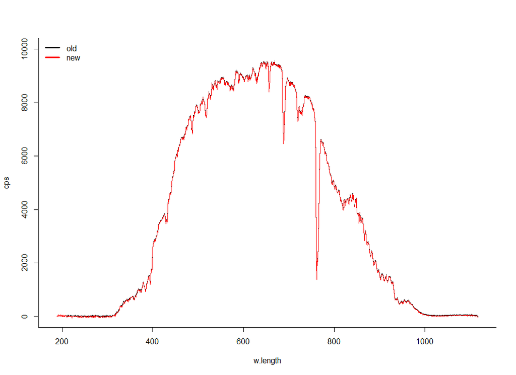

## 10. Slit function tail correction

At the end the slit function tail correction is done. The function is taken from **worker.fun** in correction.method.

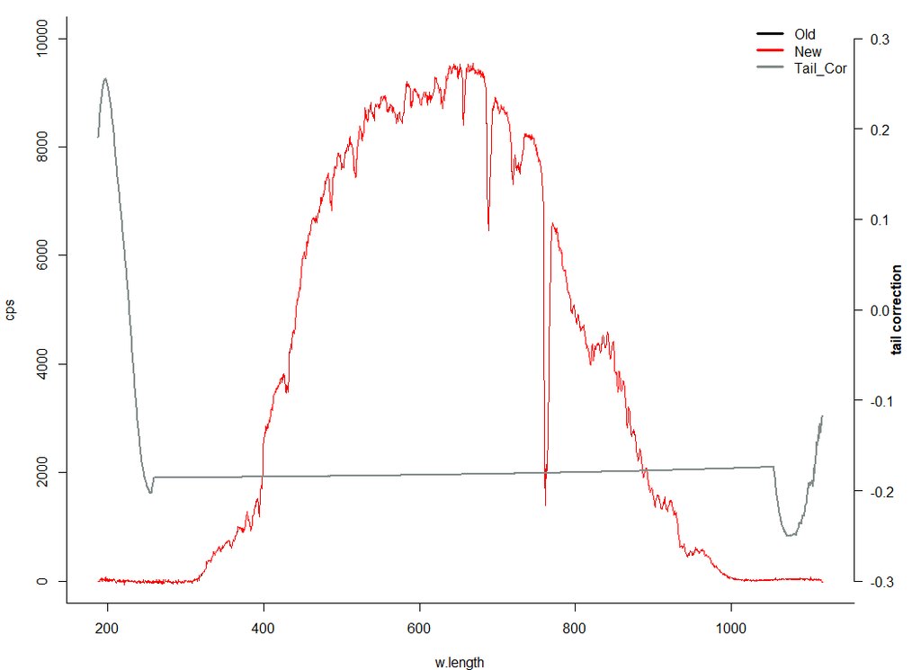

```r
worker.fun = get(correction.method[["worker.fun"]], mode = "function")
new.cps <- worker.fun(z[["w.length"]], z[["cps"]])
z_old <- z # Saving for plots
z[["cps"]] <- z[["cps"]] - new.cps[["tail"]]
```

## 11. Conversion from CPS to irradiance

The final step is using a function from the photobiology package (cps2irrad). The function use the **“irrad.mult”**. Also cut the wavebands for which function is not defined (using “wl.range”).

```r
cps2irrad <- function (x.sample, pre.fun = NULL, ...)
{
    stopifnot(is.cps_spct(x.sample) && !is.null(getInstrDesc(x.sample)) &&
        !is.null(getInstrSettings(x.sample)))
    descriptor <- getInstrDesc(x.sample)
    irrad.mult <- descriptor[["inst.calib"]][["irrad.mult"]]
    if (!is.null(pre.fun)) {
        x.sample <- pre.fun(x.sample, ...)
    }
    cps.col.sample <- grep("^cps", names(x.sample), value = TRUE)
    stopifnot(length(cps.col.sample) == 1)
    z <- as.generic_spct(x.sample)
    z[[cps.col.sample]] <- NULL
    z[["s.e.irrad"]] <- x.sample[[cps.col.sample]] * irrad.mult
    setSourceSpct(z, time.unit = getTimeUnit(x.sample))
    z <- copy_attributes(x.sample, z)
    if (length(descriptor[["inst.calib"]][["wl.range"]]) ==
        2) {
        z <- clip_wl(z, descriptor[["inst.calib"]][["wl.range"]])
    }
  z
}

IRR <- cps2irrad(z)
```

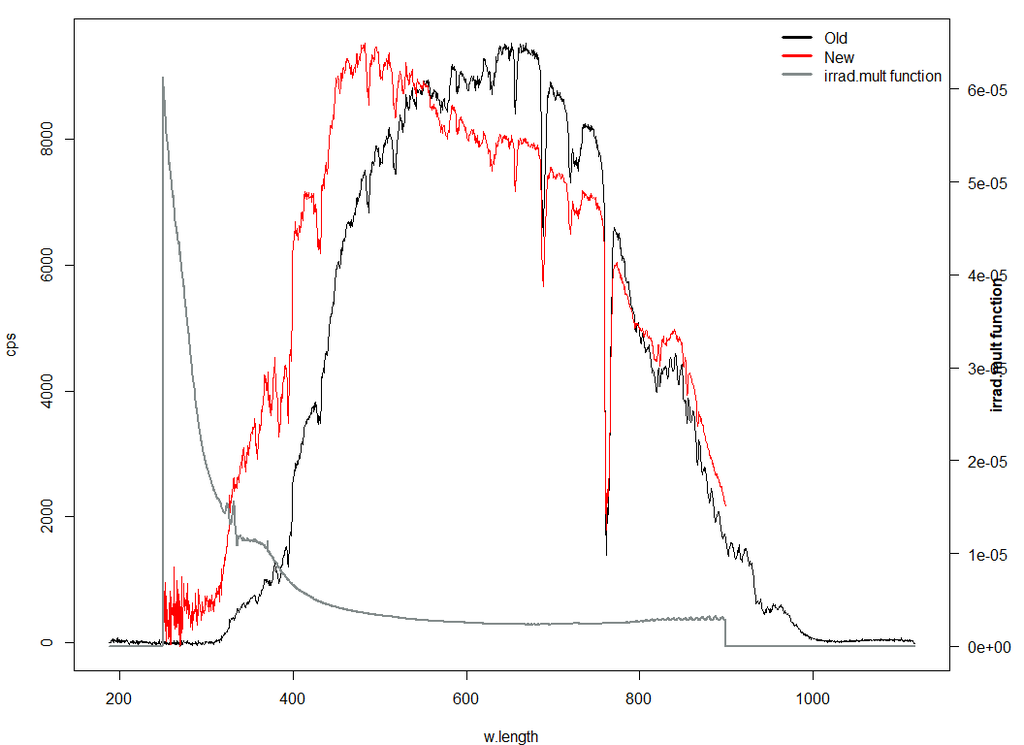

# Tests and ideas for analysis

## Smooting

**How much smoothing the default smoothing function does**  
The custom method seems to only smooth data below 320 or even 300nm (in UVb).

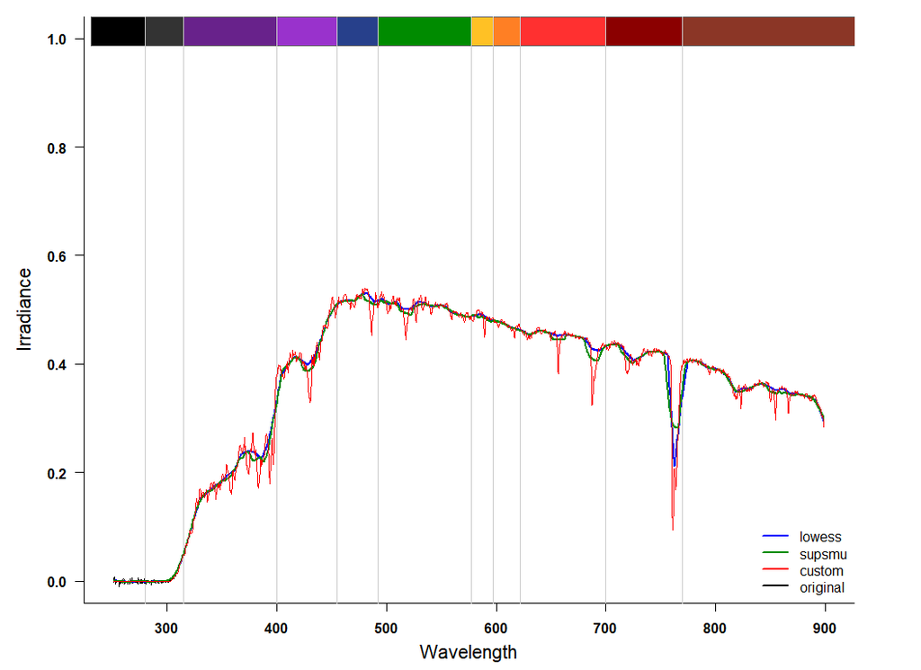

```r
# Curve 87 should be deepest curve
date = "2016-04-28"
CorMeth = MAYP11278_sun.mthd
l <- list(light = "C:/Users/Localadmin_durandma/Dropbox/Work/Misc/Trials/Spectral_Irr/2016.04.21.FI.Lammi/BetulaYoung/BeoY3sun00086.txt",
          filter = "C:/Users/Localadmin_durandma/Dropbox/Work/Misc/Trials/Spectral_Irr/2016.04.21.FI.Lammi/BetulaYoung/BeoY3sunPC.txt",
          dark = "C:/Users/Localadmin_durandma/Dropbox/Work/Misc/Trials/Spectral_Irr/2016.04.21.FI.Lammi/BetulaYoung/BeoY3sundark.txt")

spc <- s_irrad_corrected(x = l, descriptor = which_descriptor(date, verbose = F), correction.method = CorMeth, verbose = F)
spc_Scustom <- smooth_spct(spc, method = "custom") # Only really effective at w.length < 300
spc_Slowess <- smooth_spct(spc, method = "lowess")
spc_Ssupsmu <- smooth_spct(spc, method = "supsmu")
```

## Functional data analysis

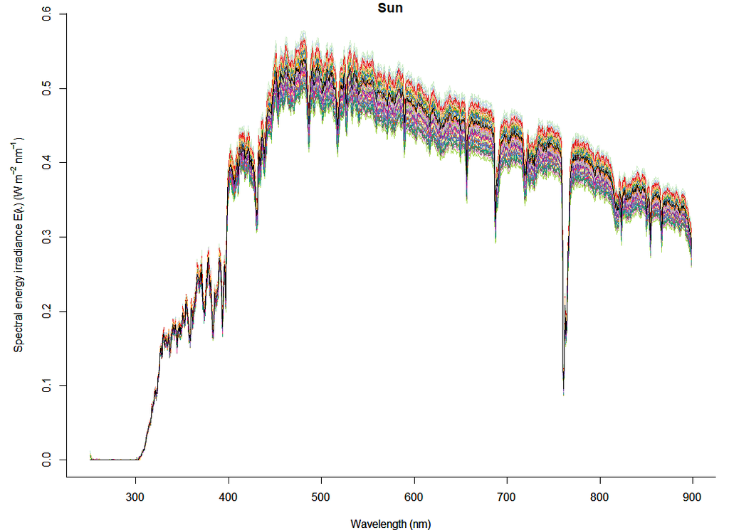

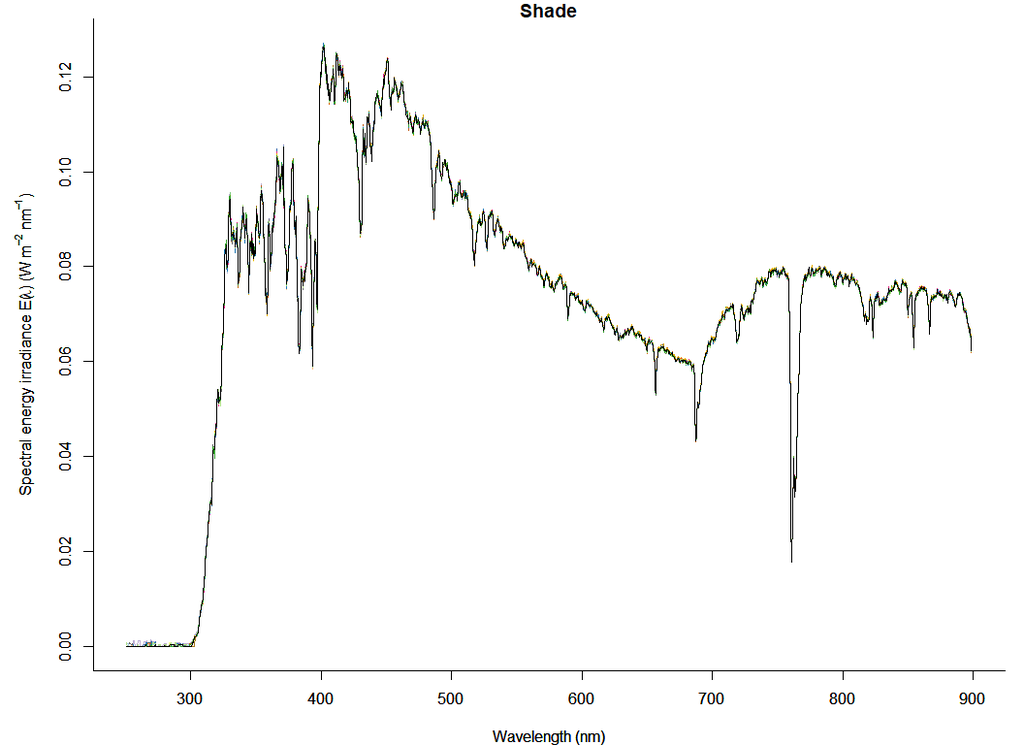

Not running this because last few takes a minute to run

```r
# Different methods to find deepest curve based around different depth functions
depth.FM(fdf)$lmed # curve 87
depth.RP(fdf)$lmed # curve 15
depth.RPD(fdf)$lmed # curve 88
depth.mode(fdf)$lmed # curve 36
depth.RT(fdf)$lmed # curve 15
depth.KFSD(fdf)$lmed # curve 34
depth.FSD(fdf)$lmed # curve 98
```

## 1st Derivative

```
## s.e.irrad52
##          52
```

```
## s.e.irrad10
##          10
```

### How smoothing impact 1st derivative calculation

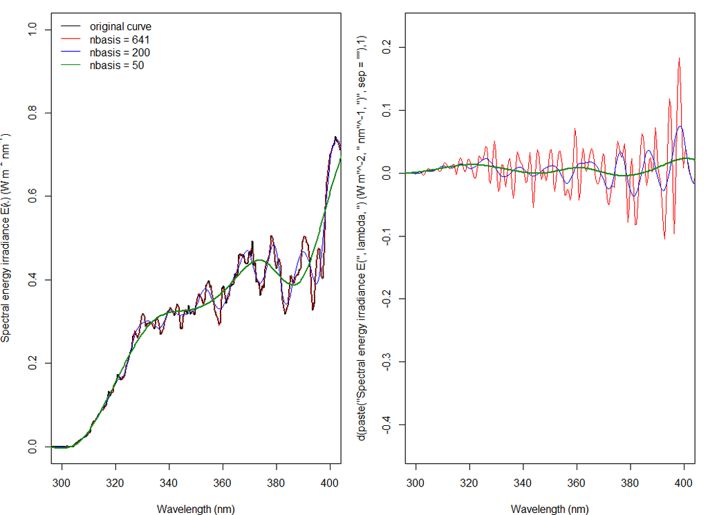

### Exemple comparison Sun/Shade

**Interesting inversion of amplitude between 440-460 nm (Why?)**

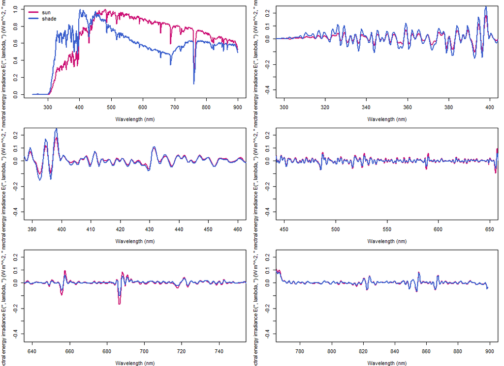

## Calculate distribution indexes

Home-made function that calculate mean, median and mode as well as SD and coefficient of variation at every wavelength from a list of spectra (norm normalize the spectra before doignthe calculations).

```r
dfS <- specStat(BY1)
dfN <- specStat(BY1, norm = T)
```

**Curious rise of CV up to 677nm, then decrease. Before 315nm, the CV is heaviliy influenced by very small deviations from the mean so very high CV.**

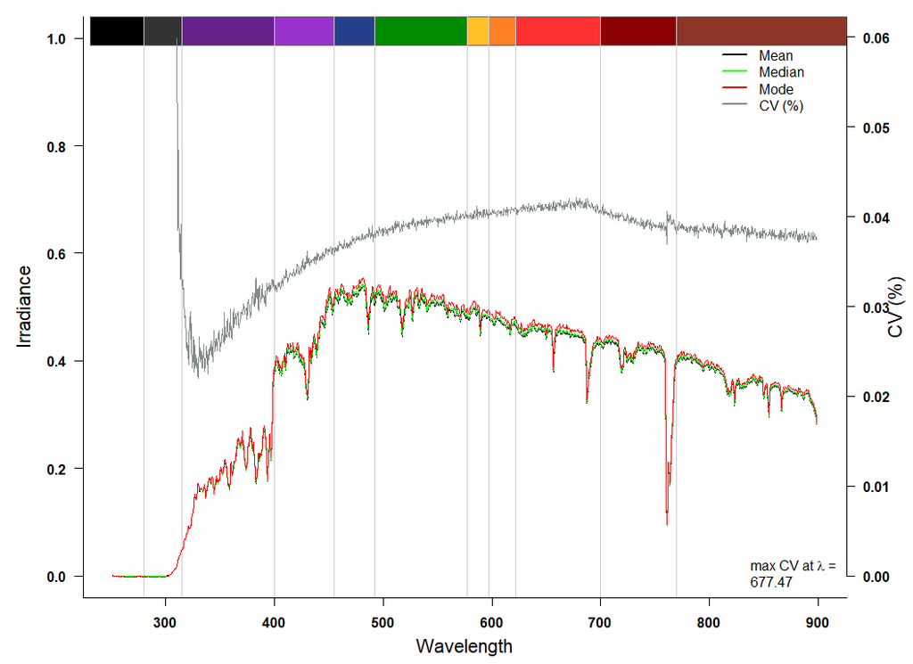

## Thick-pen transfomation

```r
### Thick-pen transformation
thickPen <- function(spec = spec, thickness = 15)
{
  df <- data.frame("w.length" = numeric(0), "low" = numeric(0), "high" = numeric(0))
  for(i in 1:nrow(spec))
  {
    LOW <- min(spec$s.e.irrad[i:ifelse(i+thickness > nrow(spec), nrow(spec), i+thickness)], na.rm = T)
    UP <- max(spec$s.e.irrad[i:ifelse(i+thickness > nrow(spec), nrow(spec), i+thickness)], na.rm = T)
    df <- rbind(df, c(spec$w.length[i],LOW,UP))
  }
  colnames(df) <- c("w.length", "lower", "upper")
  return(df)
}

calTMPA <- function(list = listTP)
{
  TMPA <- vector()
  for(i in 1:nrow(list[[1]]))
  {
    # Select "i" element of certain column "col" in list of multiple similar dataframes.
    sList <- function(iter = i, list = list, col = "upper")
    {
      if(col == "upper"){
        x <- lapply(list, subset, select = upper)
      } else if(col == "lower"){
        x <- lapply(list, subset, select = lower)
      }
      y <- matrix(unlist(x), ncol = length(x), nrow = nrow(x[[1]]), byrow = F)
      z <- as.numeric(y[iter,])
      return(z)
    }

    xTMPA <- (min(sList(i, list, "upper"))-max(sList(i, list, "lower"))) / (max(sList(i, list, "upper")) - min(sList(i, list, "lower")))
    TMPA <- append(TMPA, values = xTMPA)
  }
  TMPA[is.na(TMPA)] <- 0
  return(TMPA)
}
```

```r
spc <- BY1[[87]] # Deepest curve (sun)
spc2 <- BY1s[[8]]  # Deepest curve (shade)

# Normalization
spec <- normalize(spc)
spec2 <- normalize(spc2)

# Thinkness = 20
dfTP1 <- thickPen(spec, thickness = 20)
dfTPs1 <- thickPen(spec2, thickness = 20)
listTP1 <- list(dfTP1, dfTPs1)
TMPA1 <- calTMPA(list = listTP1)

# Thinkness = 70
dfTP2 <- thickPen(spec, thickness = 70)
dfTPs2 <- thickPen(spec2, thickness = 70)
listTP2 <- list(dfTP2, dfTPs2)
TMPA2 <- calTMPA(list = listTP2)
```

**Before normalization:**

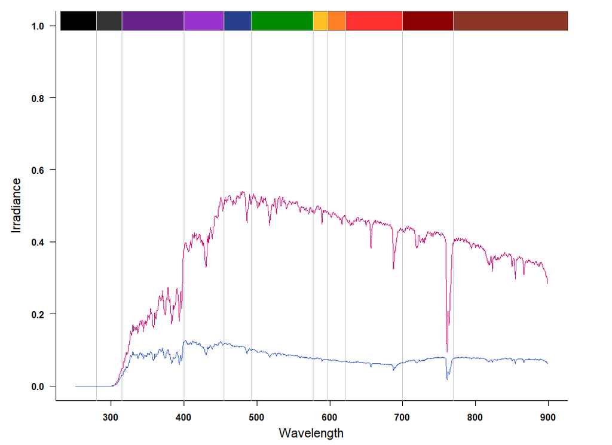

**Thick-Pen Tranformation exemple:**

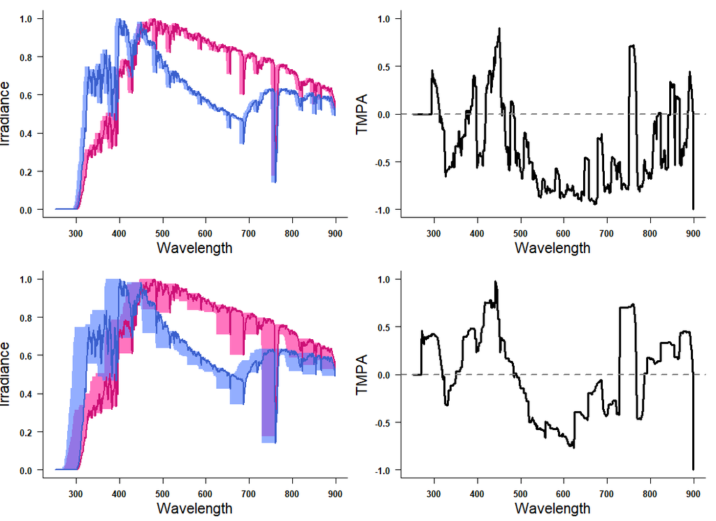

## Spectrum density plot

**A trial of plotting a density estimator of the 100 spectra. In red in the median, and darker shades of gray are for 1-99, 10-90 and 25-75 quantile, respectively.**

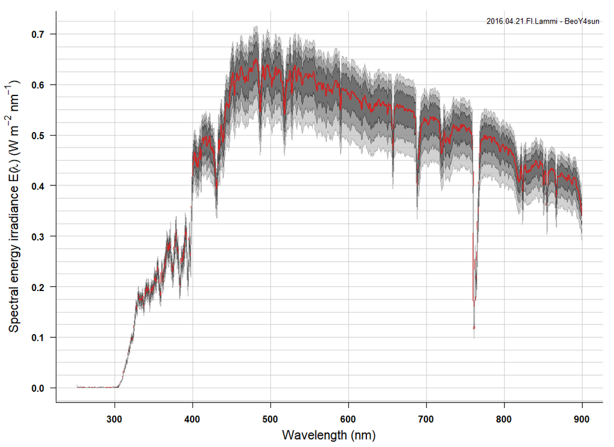

```r
source("C:/Users/Localadmin_durandma/Dropbox/Work/R/Spectral_Irr/SpecDens.R")
P <- "C:/Users/Localadmin_durandma/Dropbox/Work/Misc/Trials/Spectral_Irr/2016.04.21.FI.Lammi/BetulaYoung"
plotSpecDens(pattern = "BeoY4sun", path = P, date = "2016-04-28", CorMeth = MAYP11278_sun.mthd)
```